# 08_analysis_4

Author

Antoine Andréoletti (s242830), Olivier Gaufrès (s243252), Amy Surry (s201902), Lea Skytthe (s203531), Trine Søgaard (s204655)

# Uploading data

## Data

The data we are using in this exercise comes from here: https://ftp.ebi.ac.uk/biostudies/fire/E-MTAB-/807/E-MTAB-12807/Files/.

## Load Libraries

```r
rm(list = ls())

library("tidyverse")
library("httr")
library("XML")
library("stringr")
```

## Creating data folder

```r
data_dir <- "../data"
results_dir <- "../results"
raw_data_dir <- "../data/_raw/"
count_data_dir <- "../data/_raw/count_data"
metadata_dir <- "../data/_raw/metadata"

if( !dir.exists(data_dir) ){
  dir.create(path = data_dir)
}

if( !dir.exists(results_dir) ){
  dir.create(path = results_dir)
}

if( !dir.exists(raw_data_dir) ){
  dir.create(path = raw_data_dir)
}

if( !dir.exists(count_data_dir) ){
  dir.create(path = count_data_dir)
}

if( !dir.exists(metadata_dir) ){
  dir.create(path = metadata_dir)
}
```

## Upload data

```r
base_url <- "https://ftp.ebi.ac.uk/biostudies/fire/E-MTAB-/807/E-MTAB-12807/Files/"

# Make an HTTP GET request
response <- GET(base_url)

# Parse the HTML content
html_doc <- htmlParse(content(response, as = "text"), asText = TRUE)

# Extract file links
file_links <- xpathSApply(html_doc, "//a/@href")
file_links <- data.frame(files = file_links)

count_files <- file_links |>
  filter(str_ends(files, ".sf")) |>
  pull(files)

metadata_files <- file_links |>
  filter(str_ends(files, ".txt")) |>
  pull(files)

# Importing each file and downloading it in the right folder
base <- "../data/_raw"

# Downloading count data files
for (count_file in count_files) {
  new_file_name <- str_replace(count_file, "_quant.sf", "_quant.csv")
  new_file_path <- paste(base, "/count_data/", new_file_name,
                         sep = "")
  if (file.exists(new_file_path)) {
    next
  }
  file_path <- paste(base_url, count_file,
                     sep = "")
  file <- read_tsv(file = file_path)
  write_csv(file, file = new_file_path)
}

# Downloading metadata files
for (metadata_file in metadata_files) {
  new_file_name <- str_replace(metadata_file, ".txt", ".csv")
  new_file_path <- paste(base, "/metadata/", new_file_name,
                         sep = "")
  if (file.exists(new_file_path)) {
    next
  }
  file_path <- paste(base_url, metadata_file,
                     sep = "")
  file <- read_tsv(file = file_path)
  write_csv(file, file = new_file_path)
}
```

# Cleaning data

## Load libraries

```r
rm(list=ls())

library(tidyverse)
```

## Cleaning the meta data

Removing columns that do not show differences between patients

```r
# Read metadata
metadata <- read.csv('../data/_raw/metadata/E-MTAB-12807.sdrf.csv')

# Check for differences in columns - we only want the columns that shows differences between patients
filtered_metadata <- metadata |>
  dplyr::select(where(~ n_distinct(.) > 1))
```

Removing duplicates in rows based on source name

```r
filtered_metadata <- filtered_metadata |>
  distinct(Source.Name, .keep_all = TRUE)
```

Remove the `Assay.Name` & `Extract.Name` columns as they are the same as `Source.Name`. Furthermore, we remove columns we do not intend to use.

```r
filtered_metadata <- filtered_metadata |>
  dplyr::select(-Extract.Name,
                -Assay.Name,
                -Scan.Name,
                -Factor.Value.disease.,
                -starts_with("Comment."))
```

Renaming the columns to be more meaningful

```r
filtered_metadata <- filtered_metadata |>
  dplyr::rename(
    source_name = "Source.Name",
    individual = "Characteristics.individual.",
    age = "Characteristics.age.",
    sex = "Characteristics.sex.",
    disease = "Characteristics.disease.",
    data_file = "Derived.Array.Data.File",
    clinical_information = "Factor.Value.clinical.information."
  )
```

Inspect a sample of the cleaned data

```r
filtered_metadata |>
  sample_n(size = 5)
```

```
  source_name individual age    sex                           disease
1   77rthragf    rthragf  42 female non-alcoholic fatty liver disease
2   91recthwm    recthwm  27   male                            normal
3   98itblanf    itblanf  20 female                            normal
4   96irrynsf    irrynsf  23 female                            normal
5   73dmananm    dmananm  46   male                cirrhosis of liver
           data_file clinical_information
1 77rthragf_quant.sf         postprandial
2 91recthwm_quant.sf              fasting
3 98itblanf_quant.sf              fasting
4 96irrynsf_quant.sf         postprandial
5 73dmananm_quant.sf         postprandial
```

Saving the metadata file

```r
write_csv(filtered_metadata,
          file = file.path("../data/02_metadata_clean.csv"))
```

## Combining the count_data into a data frame

The data has the following columns:

- **Name**: The transcript IDs (e.g., ENST… are Ensemble transcript identifiers).
- **Length**: The full length of the transcript in base pairs (bp).
- **EffectiveLength**: The adjusted length accounting for sequencing biases.
- **TPM (Transcripts Per Million)**: A normalized measure of transcript abundance, commonly used in RNA-Seq data.
- **NumReads**: The raw number of reads mapped to each transcript.
- **source_name**: The patient ID

```r
# List all files in the directory
file_paths <- list.files("../data/_raw/count_data/",
                         pattern = ".csv$",
                         full.names = TRUE)

# Load and combine files into a single tibble
# ! Creates a big file !
person_data <- file_paths |>
  map(~ read.csv(.x,
                 header = TRUE,
                 sep = ",") |>
        mutate(source_name = str_remove(basename(.x),
                                        "_quant\\.csv$"))) |>
  bind_rows()
```

Inspect a sample of the combined data

```r
person_data |>
  sample_n(size = 10)
```

```
                 Name Length EffectiveLength       TPM NumReads source_name
1   ENST00000495457.1    542         353.111  0.091827    1.739   94thttecm
2   ENST00000366215.2   2085        1919.000  0.000000    0.000   58proussm
3   ENST00000491101.5    569         334.977  0.037618    1.074   73dmananm
4  ENST00000301329.10   2059        1666.167 15.442297 1379.637   94thttecm
5   ENST00000508713.1   3025        2223.117  0.019942    2.000   59antofrm
6   ENST00000503245.5    966         709.035  0.000000    0.000   78timacef
7   ENST00000476949.1    382         217.000  0.000000    0.000   40mayoicf
8   ENST00000525720.1    980         917.884  0.000000    0.000   93breninf
9  ENST00000261509.10   5809        5646.000  0.000000    0.000   48itwinyf
10  ENST00000580752.1    458         241.312  0.078727    1.000   58latelnf
```

Saving the cleaned count_data file

```r
write_csv(person_data,
          file = file.path("../data/02_count_data_long.csv"))
```

# Augmenting the data

## Load libraries

```r
rm(list = ls())

library("tidyverse")
library("biomaRt")
```

## Augment data

Loading the cleaned data

```r
metadata <- read_csv("../data/02_metadata_clean.csv")
count_data <- read_csv("../data/02_count_data_long.csv")
```

### Metadata

```r
metadata |>
  sample_n(size = 5)
```

[output not shown]

Removing excluded people from the data set

```r
metadata <- metadata |>
  dplyr::filter(disease != "excluded")
```

Converting metadata to a dataframe to set rownames

```r
metadata <- data.frame(metadata)
row.names(metadata) <- metadata |>
  pull(source_name)
```

Viewing the cleaned and augmented meta data

```r
metadata |>
  sample_n(size = 5)
```

```
          source_name individual age    sex                           disease
78timacef   78timacef    timacef  40 female non-alcoholic fatty liver disease
76anichem   76anichem    anichem  42   male                cirrhosis of liver
92torlymm   92torlymm    torlymm  26   male non-alcoholic fatty liver disease
95verintm   95verintm    verintm  23   male                            normal
94stanthm   94stanthm    stanthm  24   male                            normal
                   data_file clinical_information
78timacef 78timacef_quant.sf         postprandial
76anichem 76anichem_quant.sf         postprandial
92torlymm 92torlymm_quant.sf         postprandial
95verintm 95verintm_quant.sf              fasting
94stanthm 94stanthm_quant.sf         postprandial
```

### Count data

Pivot the count data to make some analyses

```r
count_data_wide <- count_data |>
  dplyr::select(c("Name","source_name","NumReads")) |>
  pivot_wider(names_from = source_name,
              values_from = NumReads)
```

In case we need normalized counts instead of normal counts, we can create a dataset for it

```r
normalized_count_data_wide <- count_data |>
  dplyr::select(c("Name","source_name","TPM")) |>
  pivot_wider(names_from = source_name, values_from = TPM)
```

We only want to include the patients that are present in both meta data and count data. We therefore need to make sure that the rows of the metadata corresponds to the columns of the count data

```r
common_samples <- intersect(colnames(count_data_wide), rownames(metadata))

metadata <- metadata |>
  filter(source_name %in% common_samples) |>
  mutate(rank = match(source_name, common_samples)) |>
  arrange(rank) |>
  dplyr::select(-rank)

count_data_wide <- count_data_wide |>
  dplyr::select(c("Name",all_of(common_samples)))

normalized_count_data_wide <- normalized_count_data_wide |>
  dplyr::select(c("Name",all_of(common_samples)))
```

Saving the augmented metadata file

```r
write_csv(metadata,
          file = file.path("../data/03_metadata_aug.csv"))
```

We want only rows that are different from 0

```r
count_data_wide <- count_data_wide |>
  dplyr::filter(if_all(everything(), ~ . != 0))

normalized_count_data_wide <- normalized_count_data_wide |>
  dplyr::filter(if_all(everything(), ~ . != 0))
```

Renaming the “Name” column

```r
count_data_wide <- count_data_wide |>
  dplyr::rename(transcript_ID = Name)

normalized_count_data_wide <- normalized_count_data_wide |>
  dplyr::rename(transcript_ID = Name)
```

Getting the genes from the transcript IDs

```r
# Set up the Ensembl BioMart connection
ensembl <- useEnsembl(biomart = "genes",
                      dataset = "hsapiens_gene_ensembl")

# Getting transcript IDs
transcript_ids <- count_data_wide$transcript_ID

result <- getBM(
  attributes = c("ensembl_transcript_id_version",
                 "ensembl_gene_id",
                 "hgnc_symbol"),
  filters = "ensembl_transcript_id_version",
  values = transcript_ids,
  mart = ensembl
)
```

Including the gene IDs and HUGO Gene Nomenclature Committee (HGNC) symbols

```r
# Renaming "ensembl_transcript_id" in result to mach "transcript_ID" in count_data
result <- result |>
  dplyr::rename(transcript_ID = ensembl_transcript_id_version)

# Removing any leading and/or trailing spaces
count_data_wide <- count_data_wide |>
  mutate(transcript_ID = str_trim(transcript_ID))

normalized_count_data_wide <- normalized_count_data_wide |>
  mutate(transcript_ID = str_trim(transcript_ID))

result <- result |>
  mutate(transcript_ID = str_trim(transcript_ID))

# Combine result with count_data based on transcript_ID
count_data_combined <- count_data_wide |>
  left_join(result, by = "transcript_ID")

normalised_count_data_combined <- normalized_count_data_wide |>
  left_join(result, by = "transcript_ID")
```

Renaming and relocating the new columns

```r
# for the count data
count_data_combined <- count_data_combined |>
  dplyr::rename(gene_id = ensembl_gene_id,
                gene_symbol = hgnc_symbol)

count_data_combined <- count_data_combined |>
  relocate(gene_id,
           gene_symbol,
           .after = transcript_ID)

# for the normalized count data
normalised_count_data_combined <- normalised_count_data_combined |>
  dplyr::rename(gene_id = ensembl_gene_id,
                gene_symbol = hgnc_symbol)

normalised_count_data_combined <- normalised_count_data_combined |>
  dplyr::relocate(gene_id, gene_symbol, .after = transcript_ID)
```

Saving the augmented count_data file

```r
write_csv(count_data_combined,
          file = file.path("../data/03_count_data_wide_aug.csv"))

write_csv(normalised_count_data_combined,
          file = file.path("../data/03_normalized_count_data_wide_aug.csv"))
```

# First description of the data

## Load libraries

```r
rm(list=ls())

library("tidyverse")
library("table1")
library("patchwork")
```

## Load data

```r
metadata <- read_csv("../data/03_metadata_aug.csv")
```

```r
metadata |> sample_n(5)
```

```
# A tibble: 5 × 7
  source_name individual   age sex    disease     data_file clinical_information
  <chr>       <chr>      <dbl> <chr>  <chr>       <chr>     <chr>
1 78timacef   timacef       40 female non-alcoho… 78timace… postprandial
2 85cestwam   cestwam       35 male   non-alcoho… 85cestwa… fasting
3 48itwinyf   itwinyf       71 female cirrhosis … 48itwiny… postprandial
4 94stanthm   stanthm       24 male   normal      94stanth… postprandial
5 95verintm   verintm       23 male   normal      95verint… fasting
```

Making a table of our data

```r
metadata |>
  mutate(sex = factor(sex),
         disease = factor(disease)) |>
  table1(x = formula(~ sex + age | disease),
         data = _)
```

|  | cirrhosis of liver (N=9) | non-alcoholic fatty liver disease (N=9) | normal (N=9) | Overall (N=27) |
| --- | --- | --- | --- | --- |
| sex |  |  |  |  |
| female | 4 (44.4%) | 5 (55.6%) | 5 (55.6%) | 14 (51.9%) |
| male | 5 (55.6%) | 4 (44.4%) | 4 (44.4%) | 13 (48.1%) |
| age |  |  |  |  |
| Mean (SD) | 60.9 (11.2) | 45.1 (18.1) | 24.6 (2.83) | 43.5 (19.3) |
| Median [Min, Max] | 62.0 [42.0, 75.0] | 42.0 [20.0, 79.0] | 24.0 [20.0, 28.0] | 42.0 [20.0, 79.0] |

## Analysing age, gender, and disease distributions

Lets start with age and sex

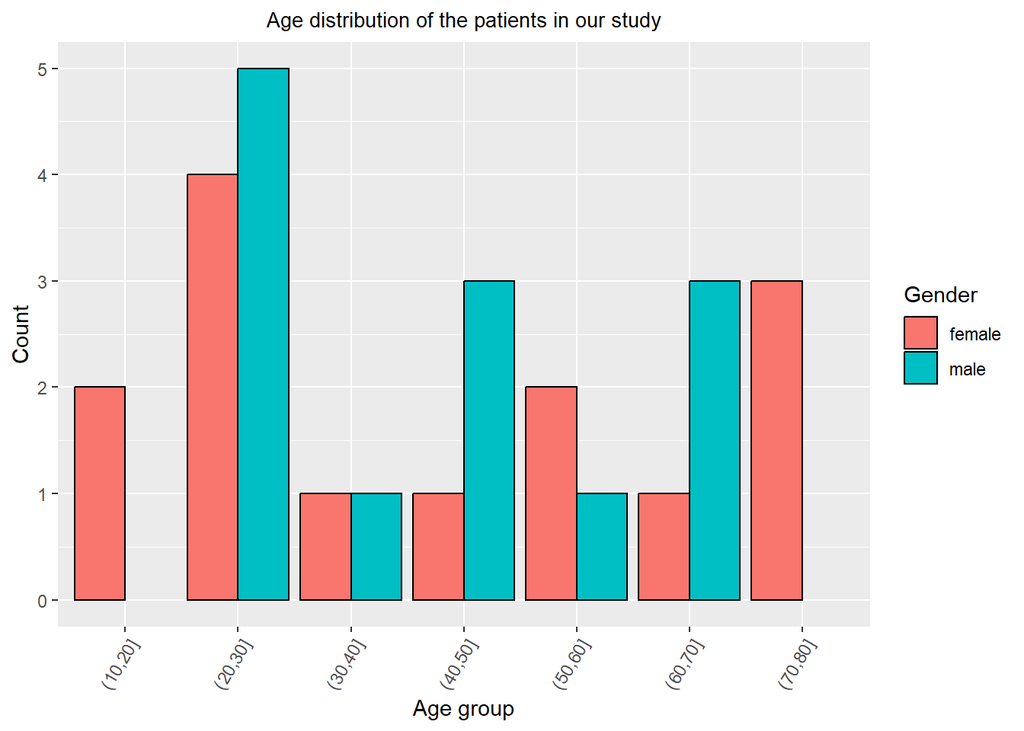

```r
p1 <- metadata |>
  mutate(age_group = cut(
    x = age,
    breaks = seq(from = 0,
                 to = 100,
                 by = 10))) |>
  ggplot(mapping = aes(x = age_group,
                       fill = sex)) +
  geom_histogram(stat = "count",
                 position = position_dodge(preserve = "single"),
                 color = "black") +
  labs(title = "Age distribution of the patients in our study",
       x = "Age group",
       y = "Count",
       fill = "Gender") +
  theme(plot.title = element_text(hjust = 0.5, size = 10),
        axis.text.x = element_text(angle = 60, hjust = 1))

p1
```

Now lets look at disease distribution in our dataset

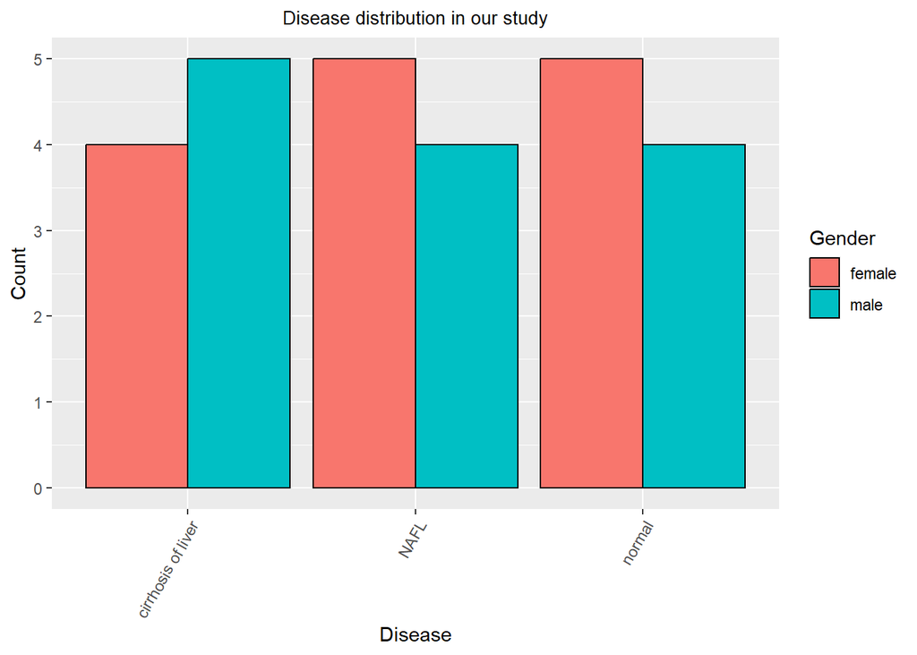

```r
p2 <- metadata |>
  mutate(disease = str_replace(disease,
                             "non-alcoholic fatty liver disease",
                             "NAFL")) |>
  ggplot(mapping = aes(x = disease, fill = sex)) +
  geom_histogram(stat = "count",
                 position = position_dodge(preserve = "single"),
                 color = "black") +
  labs(title = "Disease distribution in our study",
       x = "Disease",
       y = "Count",
       fill = "Gender") +
  theme(plot.title = element_text(hjust = 0.5, size = 10),
        axis.text.x = element_text(angle = 60, hjust = 1))

p2
```

Do the diseases depend on age?

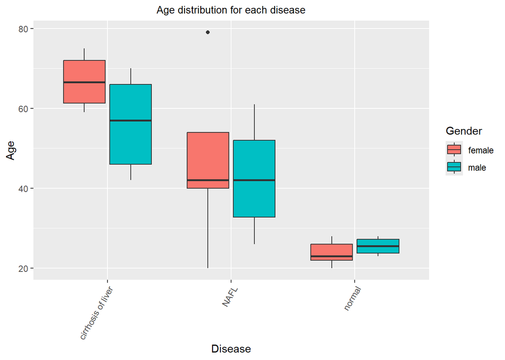

```r
p3 <- metadata |>
  mutate(disease = str_replace(disease,
                               "non-alcoholic fatty liver disease",
                               "NAFL")) |>
  ggplot(mapping = aes(x = disease, y = age, fill = sex)) +
    geom_boxplot() +
  labs(title = "Age distribution for each disease",
       x = "Disease",
       y = "Age",
       fill = "Gender") +
  theme(plot.title = element_text(hjust = 0.5, size = 10),
        axis.text.x = element_text(angle = 60, hjust = 1))

p3
```

Lets make a statistical analysis to see if there is any significant difference in the average age of people with cirrhosis disease as it looks like in the above plot.

```r
male_cirrhosis <- metadata |>
  filter(sex == "male",
         disease == "cirrhosis of liver") |>
  pull(age)

female_cirrhosis <- metadata |>
  filter(sex == "female",
         disease == "cirrhosis of liver") |>
  pull(age)

p_value <- t.test(male_cirrhosis, female_cirrhosis)$p.value
print(paste("The p-value is:", round(p_value,3)))
```

```
[1] "The p-value is: 0.157"
```

The p-value is above 0.05 so we can say that there is no significant difference between the two groups.

## Fasting vs postprandial

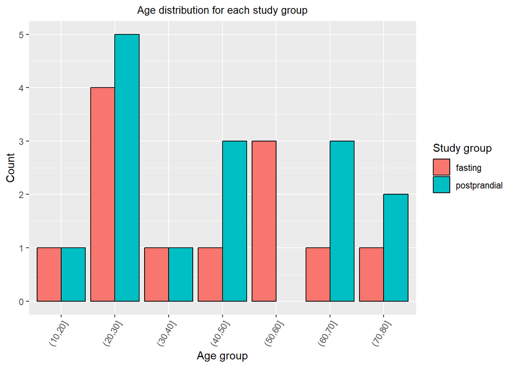

```r
p4 <- metadata |>
  mutate(age_group = cut(
    x = age,
    breaks = seq(from = 0,
                 to = 100,
                 by = 10))) |>
  ggplot(mapping = aes(x = age_group,
                       fill = clinical_information)) +
  geom_histogram(stat = "count",
                 position = position_dodge(preserve = "single"),
                 color = "black") +
  labs(title = "Age distribution for each study group",
       x = "Age group",
       y = "Count",
       fill = "Study group") +
  theme(plot.title = element_text(hjust = 0.5, size = 10),
        axis.text.x = element_text(angle = 60, hjust = 1))


p4
```

# PCA

#### Libraries

```r
rm(list=ls())

library("tidyverse")
library("broom")
library("cowplot")
library("ggrepel")
library("patchwork")
```

#### Data load

```r
data_pheno <- read.csv("../data/03_metadata_aug.csv")

data_counts.total <- read.csv("../data/03_count_data_wide_aug.csv",
                              check.names = FALSE)

# make matrix of count data
data_counts <- data_counts.total |>
  dplyr::select(-gene_id, -gene_symbol, -transcript_ID) |>
  mutate(across(where(is.numeric), as.integer))


# Doing the PCA
pca_fit <- data_counts |>
  scale() |> # scaling data
  t() |> # transpose data
  prcomp() # make the PCA
```

We would like to:

1. Look at the variance explained by each PC.
2. Look at the data in PC coordinates.
3. Look at the rotation matrix.

#### The variance by each PC

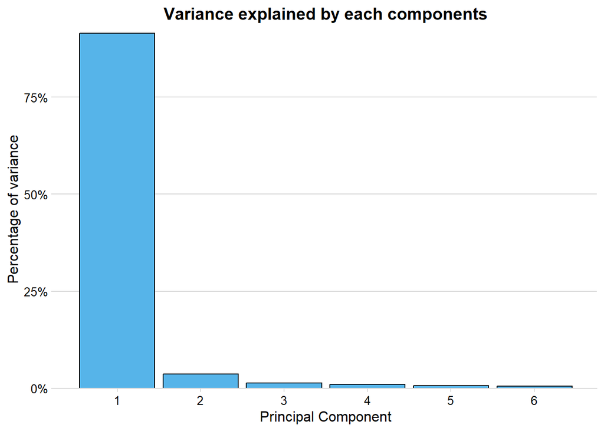

```r
pca_fit |>
  tidy(matrix = "eigenvalues") |>
  filter(percent > 0.005) |>
  ggplot(aes(x = PC,
             y = percent)) +
  geom_col(fill = "#56B4E9", color = "black") +
  scale_x_continuous(breaks = 1:length(data_counts)) +
  scale_y_continuous(labels = scales::percent_format(),
                     expand = expansion(mult = c(0, 0.01))) +
  theme_minimal_hgrid(12) +
  labs(title = "Variance explained by each components",
       x = "Principal Component",
       y = "Percentage of variance") +
  theme(plot.title = element_text(hjust = 0.5))
```

```r
# Extract the percentage of variance explained by each PC
variance_explained <- pca_fit |>
  tidy(matrix = "eigenvalues") |>
  filter(PC %in% c(1, 2)) |>
  dplyr::select(PC, percent)
```

#### The data in PC coordinates

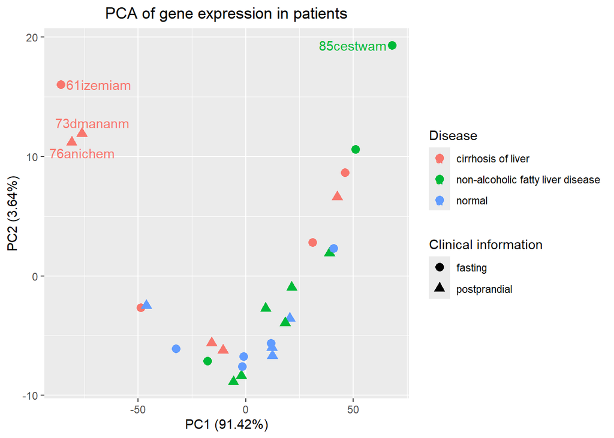

```r
coord_pca <- pca_fit |>
  augment(data_pheno) |> # add metadata
  mutate(label_points = ifelse(
    (.fittedPC1 < -50 & .fittedPC2 > 10) | (.fittedPC1 > 50 & .fittedPC2 > 15),
    source_name, NA)) |>  #new variable to specify which points should be labeled
  ggplot(aes(x = .fittedPC1,
             y = .fittedPC2,
             shape = clinical_information,
             col = disease,
             label = label_points)) +
    geom_point(size = 3) +
    geom_text_repel() +
    labs(title = "PCA of gene expression in patients",
         x = paste("PC1 (", round(variance_explained$percent[1] * 100, 2), "%)",
                   sep = ""),
         y = paste("PC2 (", round(variance_explained$percent[2] * 100, 2), "%)",
                   sep = ""),
         color = "Disease",
         shape = "Clinical information") +
    theme(plot.title = element_text(hjust = 0.5))

coord_pca
```

It is hard to split our patients just using a PCA, we will have to use other tools to look at differences in gene expression between the groups.

#### The rotation matrix

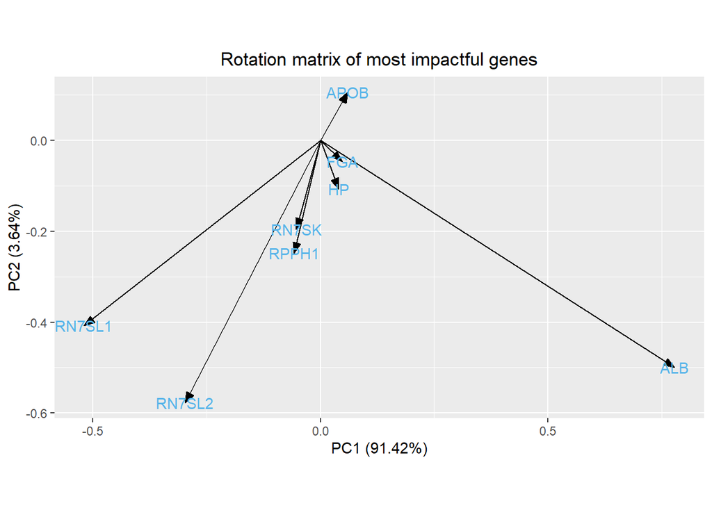

```r
# Define arrow style for plotting
arrow_style <- arrow(
  angle = 20,
  ends = "first",
  type = "closed",
  length = grid::unit(8, "pt")
)

# Lets keep only the genes with biggest impact on the PCA
PC1_sorted <- pca_fit |>
  tidy(matrix = "rotation") |>
  pivot_wider(names_from = "PC",
              names_prefix = "PC",
              values_from = "value") |>
  mutate(PC1 = abs(PC1)) |>
  arrange(desc(PC1)) |>
  pull(PC1)

biggest_value_PC1 <- PC1_sorted[10]

# Plot rotation matrix
rotation_pca <- pca_fit |>
  tidy(matrix = "rotation") |>
  pivot_wider(names_from = "PC",
              names_prefix = "PC",
              values_from = "value") |>
  mutate(column = data_counts.total$gene_symbol) |>
  filter(PC1 > biggest_value_PC1 | PC1 < - biggest_value_PC1,
         PC2 > biggest_value_PC1 | PC2 < - biggest_value_PC1) |>
  ggplot(aes(x = PC1,
             y = PC2)) +
  geom_segment(xend = 0,
               yend = 0,
               arrow = arrow_style) +
  geom_text(
    aes(label = column),
    color = "#56B4E9"
  ) +
  coord_fixed() +
  labs(title = "Rotation matrix of most impactful genes",
         x = paste("PC1 (", round(variance_explained$percent[1] * 100, 2), "%)",
                   sep = ""),
         y = paste("PC2 (", round(variance_explained$percent[2] * 100, 2), "%)",
                   sep = "")) +
  theme(plot.title = element_text(hjust = 0.5))

rotation_pca
```

# Heatmap

## Libraries

```r
rm(list=ls())

library("tidyverse")
library("pheatmap")

source(file.path("99_proj_func.R"))
```

## Load data

```r
data_pheno <- read.csv("../data/03_metadata_aug.csv")

# We want patients as row names, so we convert the tibble to a dataframe and names the rows
data_pheno <- data.frame(data_pheno) |>
  column_to_rownames("source_name")

data_counts.total <- read.csv("../data/03_count_data_wide_aug.csv")

# We want genes as row names, so we convert the tibble to a dataframe and names the rows
data_counts <- data.frame(data_counts.total) |>
  dplyr::select(-gene_id, -gene_symbol, -transcript_ID)

colnames(data_counts) <- colnames(data_counts) |>
  substring(2)

# The output of the mapping algorithm they use is an estimated number of reads mapped to each gene. It is a float while we need an integer. We will then convert it.
data_counts <- data_counts |>
  mutate(across(where(is.numeric), as.integer))
```

## The Analysis - Heatmap

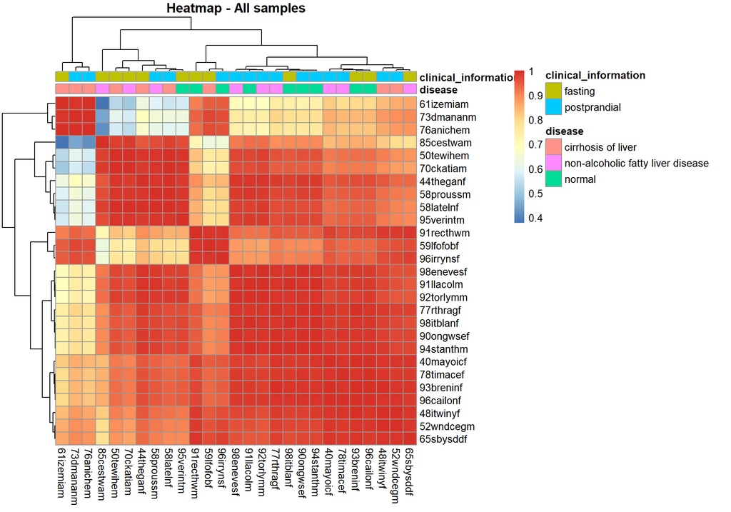

```r
cor.matrix <- cor(data_counts)
annotations <- data_pheno |>
  dplyr::select(disease,
                clinical_information)

heatmap.individual <- pheatmap(cor.matrix,
                               annotation_col = annotations,
                               main = "Heatmap - All samples")
```

# Differential Expression Analysis

```r
rm(list=ls())

library("tidyverse")
library("pheatmap")
library("ggrepel")
library("DESeq2") # DEA libraries

source(file.path("99_proj_func.R"))
```

## Load data

```r
data_pheno <- read.csv("../data/03_metadata_aug.csv")

# We want patients as row names, so we convert the tibble to a dataframe and names the rows
data_pheno <- data.frame(data_pheno) |>
  column_to_rownames("source_name")

data_counts.total <- read.csv("../data/03_count_data_wide_aug.csv")

# We want genes as row names, so we convert the tibble to a dataframe and names the rows
data_counts <- data.frame(data_counts.total) |>
  dplyr::select(-gene_id, -gene_symbol, -transcript_ID)

colnames(data_counts) <- colnames(data_counts) |>
  substring(2)

# The output of the mapping algorithm they use is an estimated number of reads mapped to each gene. It is a float while we need an integer. We will then convert it.
data_counts <- data_counts |>
  mutate(across(where(is.numeric), as.integer))
```

## Differential Expression Analysis

### Using DESeq2

```r
dds <- DESeqDataSetFromMatrix(countData = data_counts,
                              colData = data_pheno,
                              design = ~disease)

featureData <- data.frame(gene=rownames(data_counts))
mcols(dds) <- DataFrame(mcols(dds),
                        featureData)

# Adding the reference level (normal)
dds$disease <- relevel(dds$disease,
                       ref = "normal")

# DEA
dds <- DESeq(dds)
res <- results(dds)

gene_symbol.df <- data_counts.total |>
  dplyr::select(gene_symbol) |>
  rownames_to_column("transcript_ID")

res <- as.data.frame(res) |>
  rownames_to_column("transcript_ID") |>
  left_join(gene_symbol.df,
            by = "transcript_ID")

# Creating the folder to save the data

DESeq2_data_dir <- "../data/DESeq2"
if( !dir.exists(DESeq2_data_dir) ){
  dir.create(path = DESeq2_data_dir)
}

#Saving the results
write_csv(as.data.frame(res),
          file.path("../data/DESeq2/03_DESeq2_results-global.csv"))
```

### Volcano plots

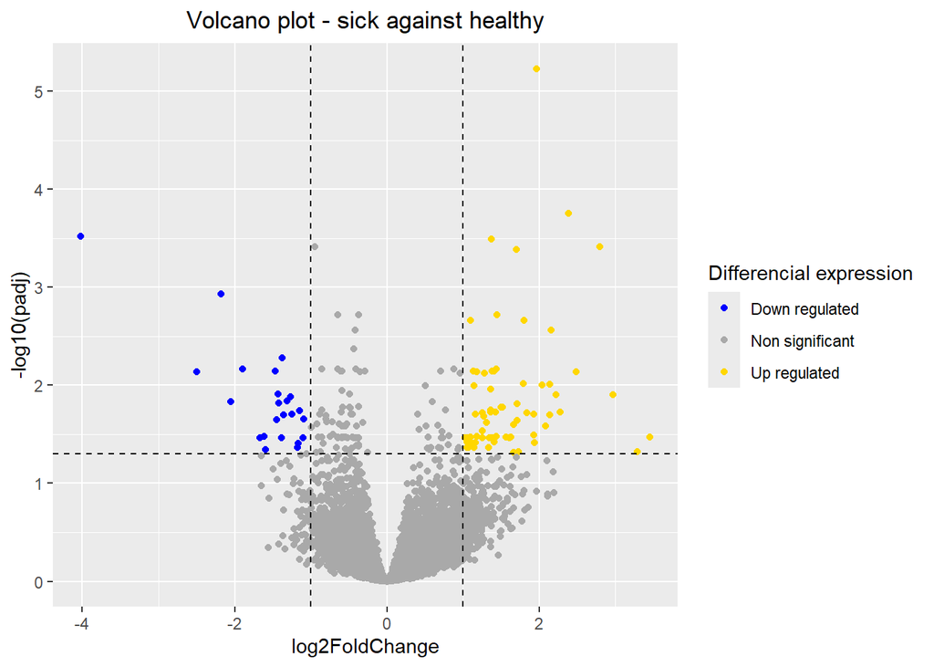

```r
# General analysis
plot_volcano(x = res,
             title = "general",
             title_plot = "sick against healthy",
             fc_cutoff = log2(2),
             p_cutoff = 0.05)
```

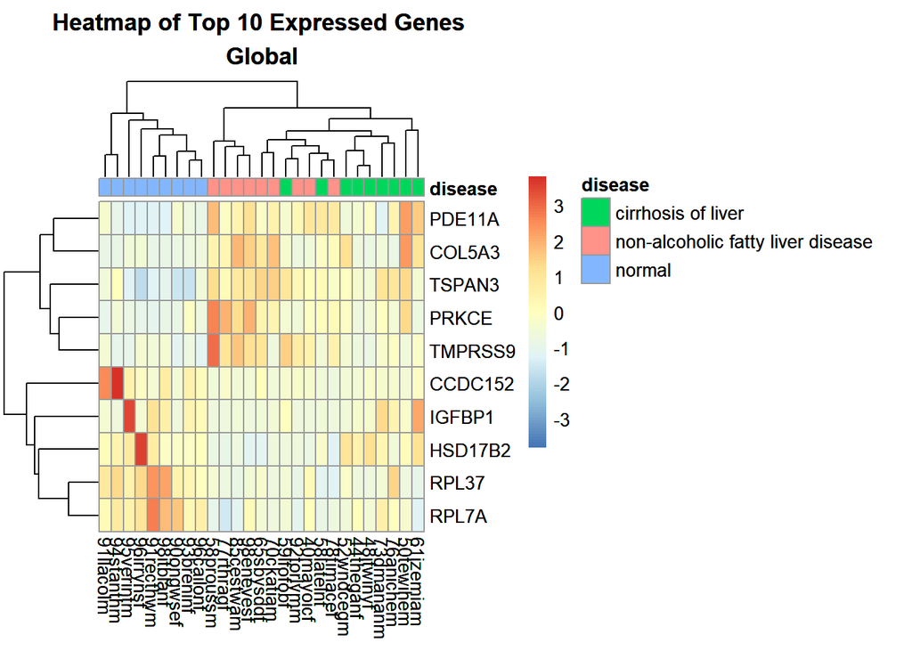

```r
annotation_data_pheno <- data_pheno |>
  dplyr::select(disease)

plot_topN_heatmap(res = res,
                  dds = dds,
                  N = 10,
                  annotation_data_pheno = annotation_data_pheno,
                  title = "global",
                  title_plot = "Global")
```

## Testing now in fasting conditions

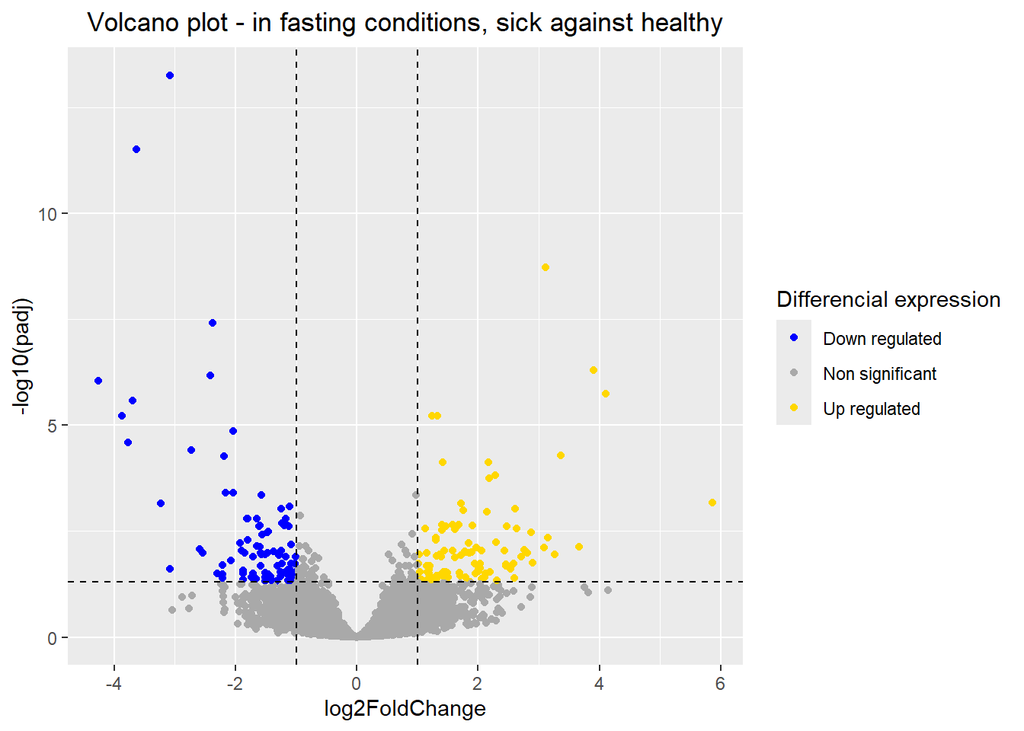

```r
data_pheno_fasting <- data_pheno |>
  dplyr::filter(clinical_information == "fasting")

data_counts_fasting <- data_counts |>
  dplyr::select(rownames(data_pheno_fasting))

dds <- DESeqDataSetFromMatrix(countData = data_counts_fasting,
                              colData = data_pheno_fasting,
                              design = ~disease)

featureData <- data.frame(gene=rownames(data_counts_fasting))
mcols(dds) <- DataFrame(mcols(dds),
                        featureData)

# Adding the reference level (normal)
dds$disease <- relevel(dds$disease, ref = "normal")

# DEA
dds <- DESeq(dds)
res <- results(dds)

gene_symbol.df <- data_counts.total |>
  dplyr::select(gene_symbol) |>
  rownames_to_column("transcript_ID")

res <- as.data.frame(res) |>
  rownames_to_column("transcript_ID") |>
  left_join(gene_symbol.df,
            by = "transcript_ID")

#Saving the results
write_csv(as.data.frame(res),
          file.path("../data/DESeq2/03_DESeq2_results-fasting.csv"))

plot_volcano(x = res,
             title = "fasting",
             title_plot = "in fasting conditions, sick against healthy",
             fc_cutoff = log2(2),
             p_cutoff = 0.05)
```

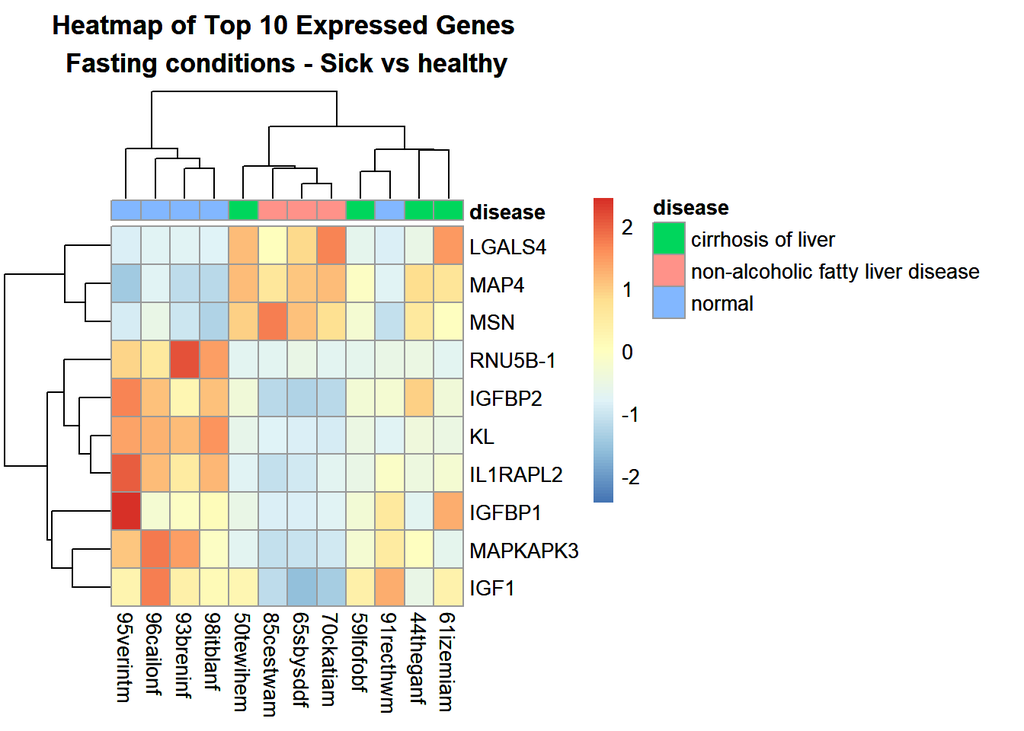

```r
annotation_data_pheno <- data_pheno_fasting |>
  dplyr::select(disease)

plot_topN_heatmap(res = res,
                  dds = dds,
                  N = 10,
                  annotation_data_pheno = annotation_data_pheno,
                  title = "fasting",
                  title_plot = "Fasting conditions - Sick vs healthy")
```

## Testing now in postprandial condition

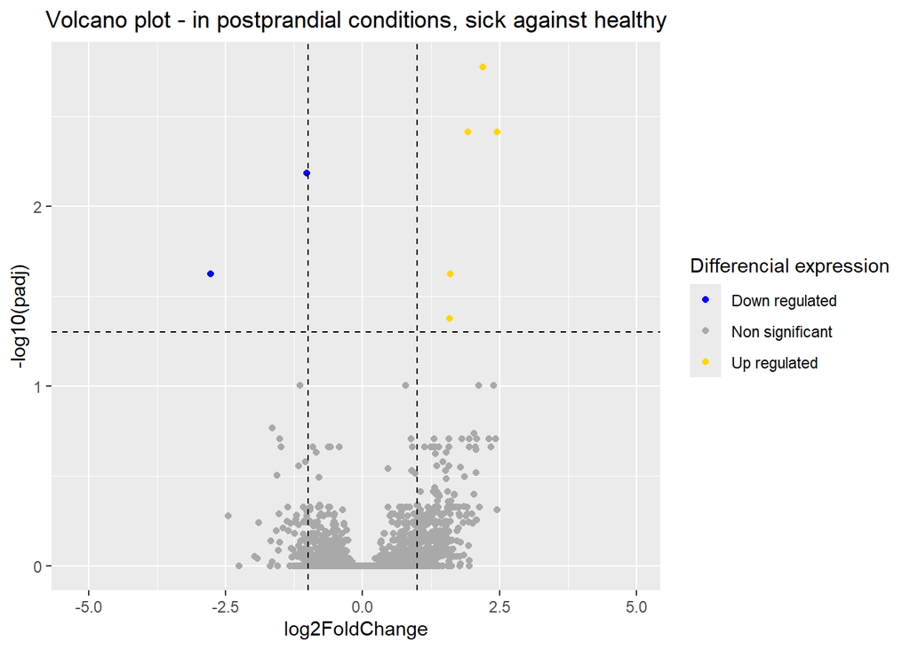

```r
data_pheno_postprandial <- data_pheno |>
  dplyr::filter(clinical_information == "postprandial")

data_counts_postprandial <- data_counts |>
  dplyr::select(rownames(data_pheno_postprandial))

dds <- DESeqDataSetFromMatrix(countData = data_counts_postprandial,
                              colData = data_pheno_postprandial,
                              design = ~disease)

featureData <- data.frame(gene=rownames(data_counts_postprandial))
mcols(dds) <- DataFrame(mcols(dds),
                        featureData)

# Adding the reference level (normal)
dds$disease <- relevel(dds$disease,
                       ref = "normal")

# DEA
dds <- DESeq(dds)
res <- results(dds)

gene_symbol.df <- data_counts.total |>
  dplyr::select(gene_symbol) |>
  rownames_to_column("transcript_ID")

res <- as.data.frame(res) |>
  rownames_to_column("transcript_ID") |>
  left_join(gene_symbol.df, by = "transcript_ID")

#Saving the results
write_csv(as.data.frame(res),
          file.path("../data/DESeq2/03_DESeq2_results-postprandial.csv"))

# Plot the volcano
plot_volcano(x = res,
             title = "postprandial",
             title_plot = "in postprandial conditions, sick against healthy",
             fc_cutoff = log2(2),
             p_cutoff = 0.05)
```

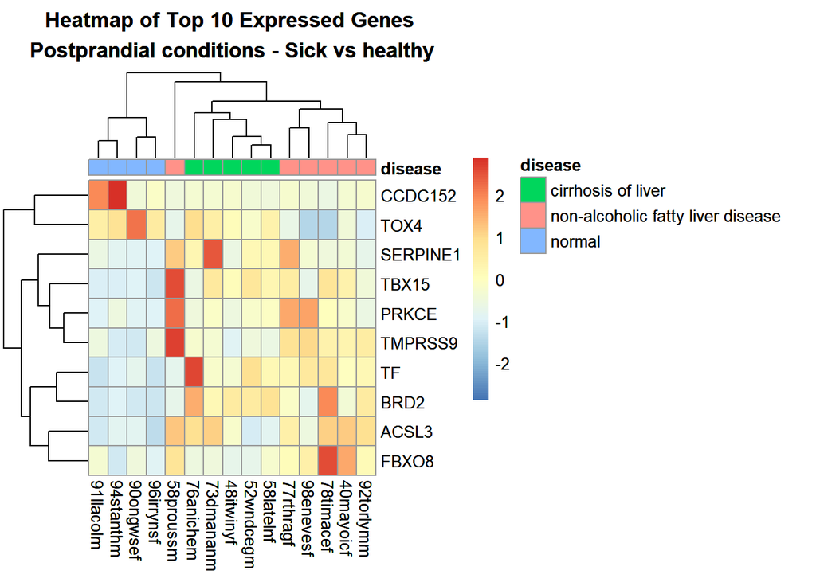

```r
annotation_data_pheno <- data_pheno_postprandial |>
  dplyr::select(disease)

plot_topN_heatmap(res = res,
                  dds = dds,
                  N = 10,
                  annotation_data_pheno = annotation_data_pheno,
                  title = "postprandial",
                  title_plot = "Postprandial conditions - Sick vs healthy")
```

## Difference in expression fasting or not cirrhosis

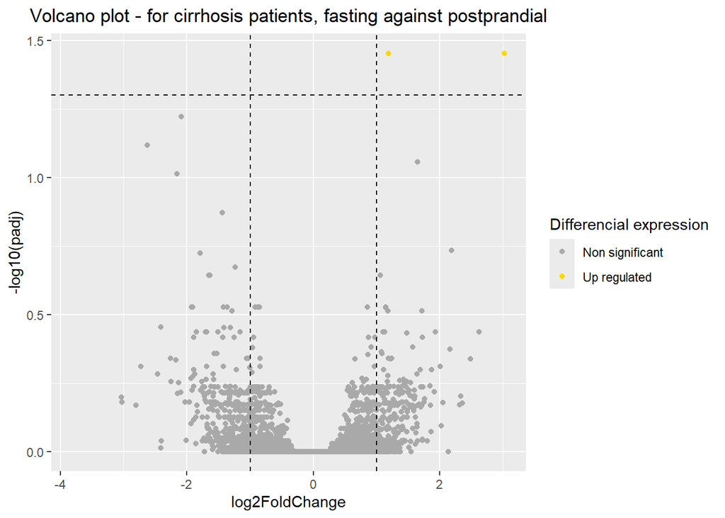

```r
data_pheno_cirrhosis <- data_pheno |>
  dplyr::filter(disease == "cirrhosis of liver")

data_counts_cirrhosis <- data_counts |>
  dplyr::select(rownames(data_pheno_cirrhosis))

dds <- DESeqDataSetFromMatrix(countData = data_counts_cirrhosis,
                              colData = data_pheno_cirrhosis,
                              design = ~clinical_information)

featureData <- data.frame(gene=rownames(data_counts_cirrhosis))
mcols(dds) <- DataFrame(mcols(dds),
                        featureData)

# DEA
dds <- DESeq(dds)
res <- results(dds)

gene_symbol.df <- data_counts.total |>
  dplyr::select(gene_symbol) |>
  rownames_to_column("transcript_ID")

res <- as.data.frame(res) |>
  rownames_to_column("transcript_ID") |>
  left_join(gene_symbol.df, by = "transcript_ID")

#Saving the results
write_csv(as.data.frame(res),
          file.path("../data/DESeq2/03_DESeq2_results-cirrhosis.csv"))

plot_volcano(x = res,
             title = "cirrhosis",
             title_plot = "for cirrhosis patients, fasting against postprandial",
             fc_cutoff = log2(2),
             p_cutoff = 0.05)
```

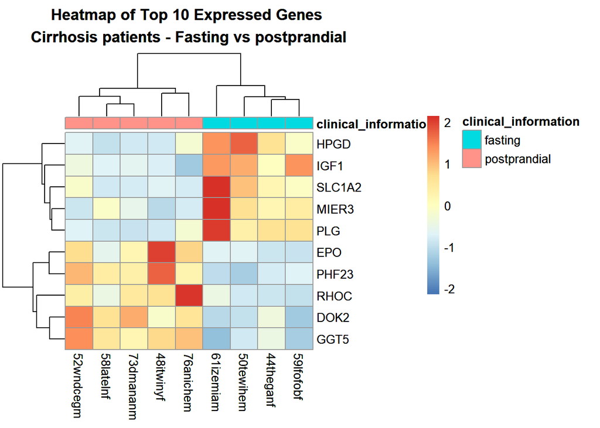

```r
annotation_data_pheno <- data_pheno_cirrhosis |>
  dplyr::select(clinical_information)

plot_topN_heatmap(res = res,
                  dds = dds,
                  N = 10,
                  annotation_data_pheno = annotation_data_pheno,
                  title = "cirrhosis",
                  title_plot = "Cirrhosis patients - Fasting vs postprandial")
```

## Difference in expression fasting or not non-alcoholic fatty liver disease

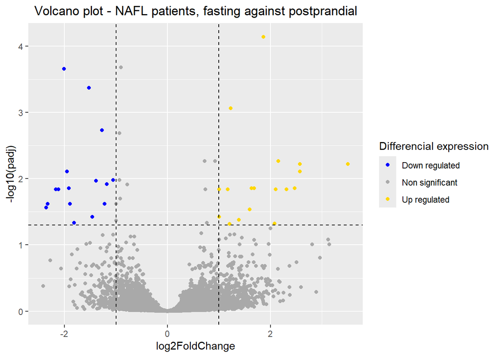

```r
data_pheno_NAFL <- data_pheno |>
  dplyr::filter(disease == "non-alcoholic fatty liver disease")

data_counts_NAFL <- data_counts |>
  dplyr::select(rownames(data_pheno_NAFL))

dds <- DESeqDataSetFromMatrix(countData = data_counts_NAFL,
                              colData = data_pheno_NAFL,
                              design = ~clinical_information)

featureData <- data.frame(gene=rownames(data_counts_NAFL))
mcols(dds) <- DataFrame(mcols(dds),
                        featureData)

# DEA
dds <- DESeq(dds)
res <- results(dds)

gene_symbol.df <- data_counts.total |>
  dplyr::select(gene_symbol) |>
  rownames_to_column("transcript_ID")

res <- as.data.frame(res) |>
  rownames_to_column("transcript_ID") |>
  left_join(gene_symbol.df, by = "transcript_ID")

#Saving the results
write_csv(as.data.frame(res),
          file.path("../data/DESeq2/03_DESeq2_results-NAFL.csv"))

plot_volcano(x = res,
             title = "NAFL",
             title_plot = "NAFL patients, fasting against postprandial",
             fc_cutoff = log2(2),
             p_cutoff = 0.05)
```

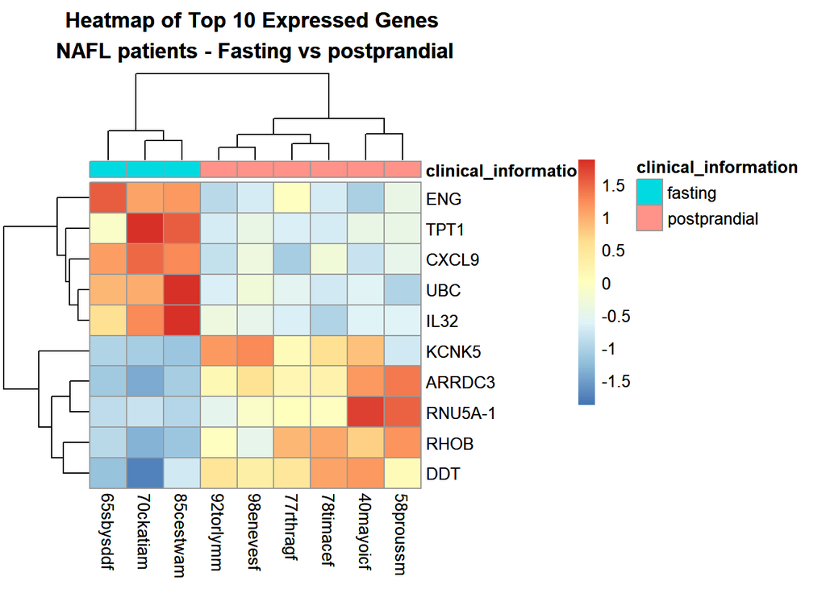

```r
annotation_data_pheno <- data_pheno_NAFL |>
  dplyr::select(clinical_information)

plot_topN_heatmap(res = res,
                  dds = dds,
                  N = 10,
                  annotation_data_pheno = annotation_data_pheno,
                  title = "NAFL",
                  title_plot = "NAFL patients - Fasting vs postprandial")
```

## Difference in expression fasting or not in healthy people

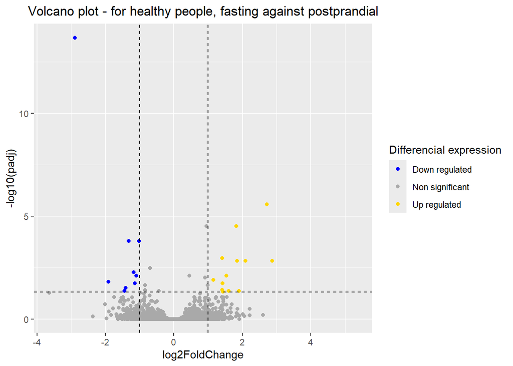

```r
data_pheno_normal <- data_pheno |>
  dplyr::filter(disease == "normal")

data_counts_normal <- data_counts |>
  dplyr::select(rownames(data_pheno_normal))

dds <- DESeqDataSetFromMatrix(countData = data_counts_normal,
                              colData = data_pheno_normal,
                              design = ~clinical_information)

featureData <- data.frame(gene=rownames(data_counts_normal))
mcols(dds) <- DataFrame(mcols(dds), featureData)

# DEA
dds <- DESeq(dds)
res <- results(dds)

gene_symbol.df <- data_counts.total |>
  dplyr::select(gene_symbol) |>
  rownames_to_column("transcript_ID")

res <- as.data.frame(res) |>
  rownames_to_column("transcript_ID") |>
  left_join(gene_symbol.df, by = "transcript_ID")

#Saving the results
write_csv(as.data.frame(res),
          file.path("../data/DESeq2/03_DESeq2_results-normal.csv"))

plot_volcano(x = res,
             title = "normal",
             title_plot = "for healthy people, fasting against postprandial",
             fc_cutoff = log2(2),
             p_cutoff = 0.05)
```

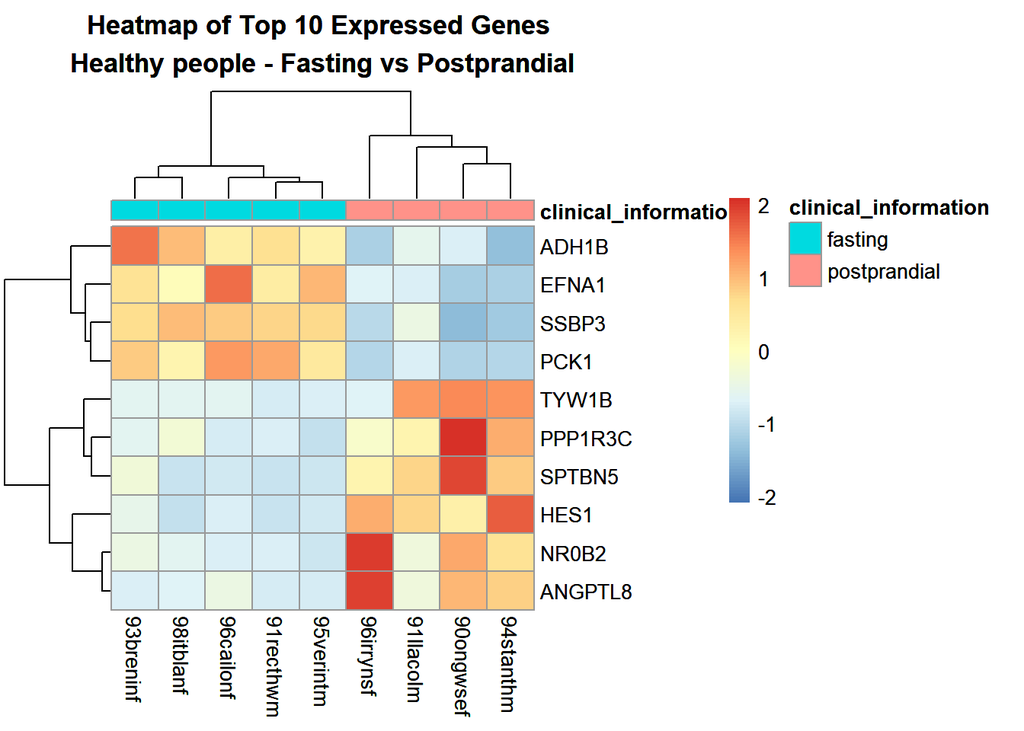

```r
annotation_data_pheno <-  data_pheno_normal |>
  dplyr::select(clinical_information)

plot_topN_heatmap(res = res,
                  dds = dds,
                  N = 10,
                  annotation_data_pheno = annotation_data_pheno,
                  title = "normal",
                  title_plot = "Healthy people - Fasting vs Postprandial")
```

# Gene Set Enrichment Analysis (GSEA)

## Load libraries

```r
rm(list=ls())

library("msigdbr")
library("clusterProfiler")
library("tidyverse")

source(file.path("99_proj_func.R"))
```

## Load data

```r
res_df <- read.csv("../data/DESeq2/03_DESeq2_results-global.csv")
```

## Data preparation

To perform Gene Set Enrichment Analysis we have to prepare data by ranking the genes and creating gene sets.

To rank the genes, we use “stat” column from the DESeq2 results. The stat column represents the test statistic and provides a standardized measure of how differentially expressed each gene is.

Furthermore, we remove missing values.

```r
# Create list of ranked genes including names
res_df <- res_df |>
  mutate(gene_symbol = na_if(gene_symbol, "")) |>
  drop_na(stat, gene_symbol) |>
  distinct(gene_symbol, .keep_all = TRUE) |>
  arrange(desc(stat))

ranked_genes <- res_df |>
  pull(stat)

gene_symbols <- res_df |>
  pull(gene_symbol)
names(ranked_genes) <- gene_symbols
```

## Gene Set Enrichment Analysis

Before performing the GSEA, we need to divide the genes into gene sets. Using the msigdbr package, the gene sets are fetched. We use category “C8” meaning cell type signature gene sets.

```r
# Get gene sets
gene_sets <- msigdbr(species = "Homo sapiens",
                     category = "C8")
```

To perform the GSEA, we use the clusterProfiler package. The function tests each gene set for significant enrichment in high- or low-ranking genes.

```r
set.seed(123)

gsea_results <- compute_GSEA(ranked_genes,
                             gene_sets)
```

Now we want to look further into the top 5 most significantly enriched pathways identified by our GSEA and plot it

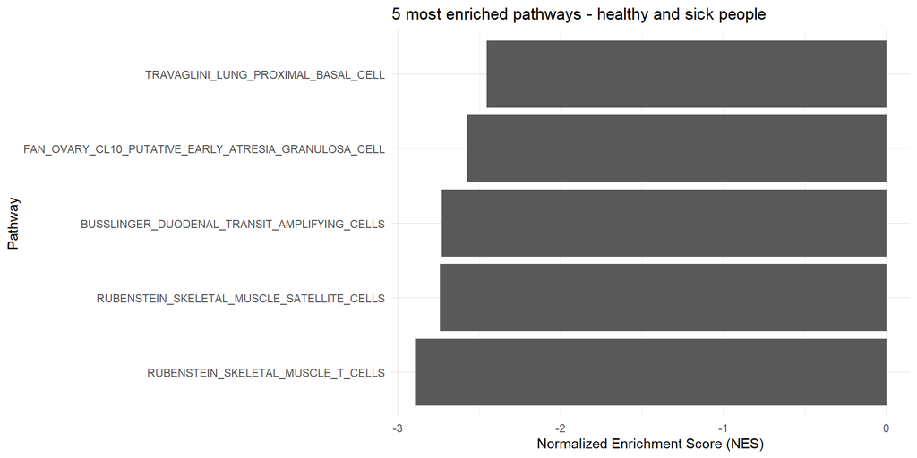

```r
title <- "5 most enriched pathways - healthy and sick people"
save_title <- "GSEA_sick_vs_healthy_people"
plot_most_enriched_pathways(gsea_results,
                            title,
                            save_title)
```

## Repeating the same procedure for each gene expression analysis we did

### Comparing expression during fasting or postprandial in cirrhosis patients

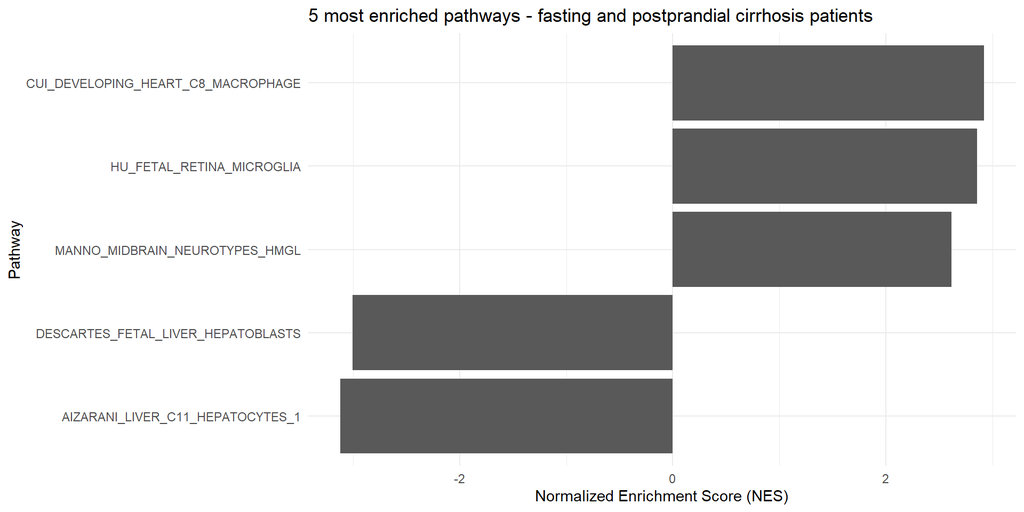

```r
res_df <- read.csv("../data/DESeq2/03_DESeq2_results-cirrhosis.csv")

# Create list of ranked genes including names
res_df <- res_df |>
  mutate(gene_symbol = na_if(gene_symbol, "")) |>
  drop_na(stat, gene_symbol) |>
  distinct(gene_symbol, .keep_all = TRUE) |>
  arrange(desc(stat))

ranked_genes <- res_df |>
  pull(stat)

gene_symbols <- res_df |>
  pull(gene_symbol)

names(ranked_genes) <- gene_symbols

gsea_results <- compute_GSEA(ranked_genes,
                             gene_sets)

title <- "5 most enriched pathways - fasting and postprandial cirrhosis patients"
save_title <- "GSEA_fasting_vs_postprandial_cirrhosis_patients"
plot_most_enriched_pathways(gsea_results,
                            title,
                            save_title)
```

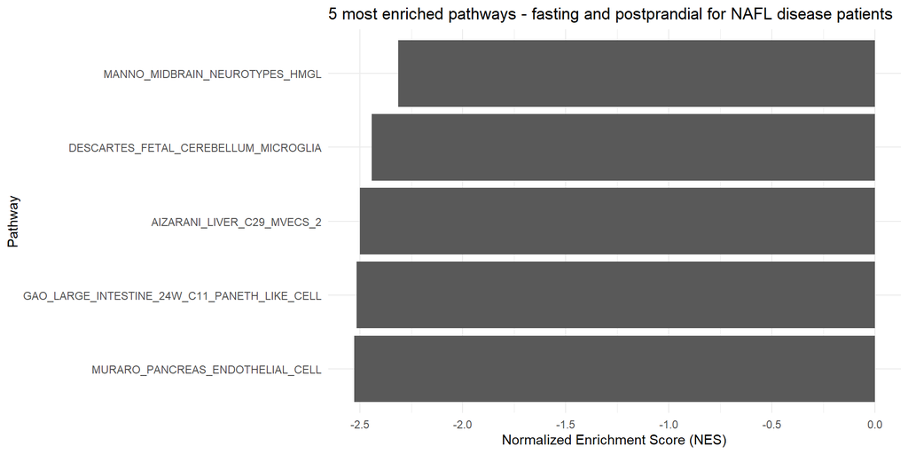

```r
res_df <- read.csv("../data/DESeq2/03_DESeq2_results-NAFL.csv")

# Create list of ranked genes including names
res_df <- res_df |>
  mutate(gene_symbol = na_if(gene_symbol, "")) |>
  drop_na(stat, gene_symbol) |>
  distinct(gene_symbol, .keep_all = TRUE) |>
  arrange(desc(stat))

ranked_genes <- res_df |>
  pull(stat)

gene_symbols <- res_df |>
  pull(gene_symbol)

names(ranked_genes) <- gene_symbols

gsea_results <- compute_GSEA(ranked_genes,
                             gene_sets)

title <- "5 most enriched pathways - fasting and postprandial for NAFL disease patients"
save_title <- "GSEA_fasting_vs_postprandial_NAFL_patients"
plot_most_enriched_pathways(gsea_results,
                            title,
                            save_title)
```

### Comparing expression during fasting or postprandial in normal patients

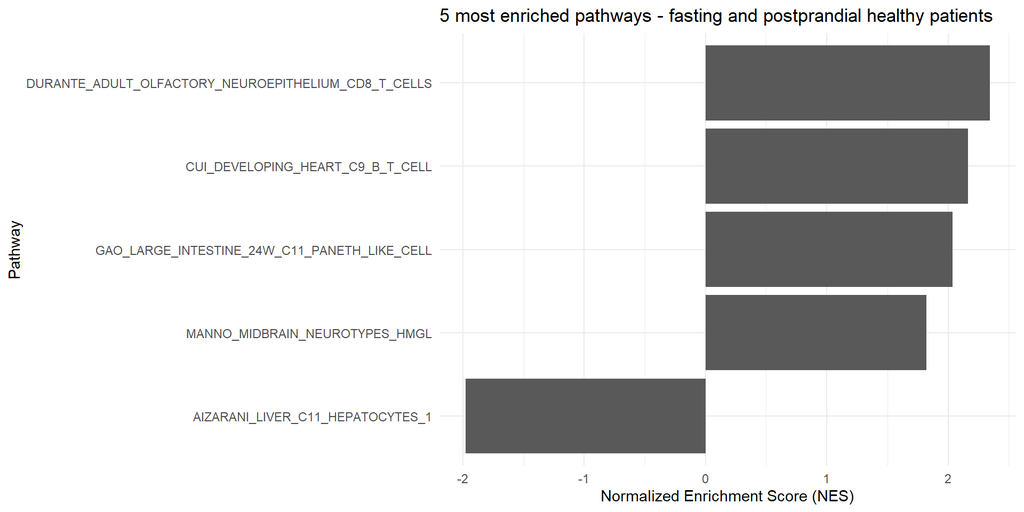

```r
res_df <- read.csv("../data/DESeq2/03_DESeq2_results-normal.csv")

# Create list of ranked genes including names
res_df <- res_df |>
  mutate(gene_symbol = na_if(gene_symbol, "")) |>
  drop_na(stat, gene_symbol) |>
  distinct(gene_symbol, .keep_all = TRUE) |>
  arrange(desc(stat))

ranked_genes <- res_df |>
  pull(stat)

gene_symbols <- res_df |>
  pull(gene_symbol)
names(ranked_genes) <- gene_symbols

gsea_results <- compute_GSEA(ranked_genes,
                             gene_sets)

title <- "5 most enriched pathways - fasting and postprandial healthy patients"
save_title <- "GSEA_fasting_vs_postprandial_healthy_patients"
plot_most_enriched_pathways(gsea_results,
                            title,
                            save_title)
```

### Comparing expression of sick or healthy patients in fasting conditions

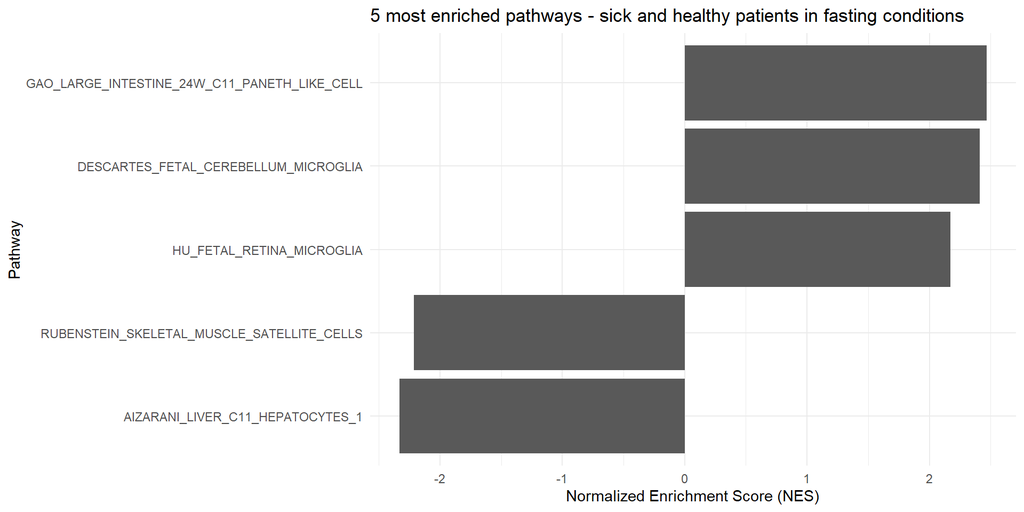

```r
res_df <- read.csv("../data/DESeq2/03_DESeq2_results-fasting.csv")

# Create list of ranked genes including names
res_df <- res_df |>
  mutate(gene_symbol = na_if(gene_symbol, '')) |>
  drop_na(stat, gene_symbol) |>
  distinct(gene_symbol, .keep_all = TRUE) |>
  arrange(desc(stat))

ranked_genes <- res_df |>
  pull(stat)

gene_symbols <- res_df |>
  pull(gene_symbol)
names(ranked_genes) <- gene_symbols

gsea_results <- compute_GSEA(ranked_genes,
                             gene_sets)

title <- "5 most enriched pathways - sick and healthy patients in fasting conditions"
save_title <- "GSEA_sick_vs_healthy_patients_fasting"
plot_most_enriched_pathways(gsea_results,
                            title,
                            save_title)
```

### Comparing expression of sick or healthy patients in postprandial conditions

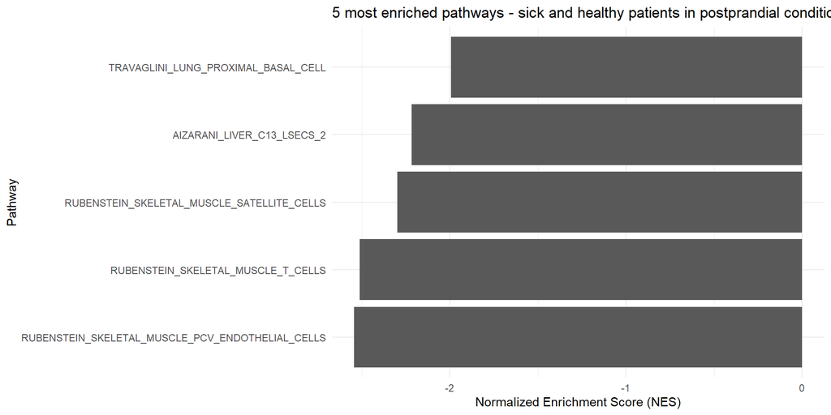

```r
res_df <- read.csv("../data/DESeq2/03_DESeq2_results-postprandial.csv")

# Create list of ranked genes including names
res_df <- res_df |>
  mutate(gene_symbol = na_if(gene_symbol, '')) |>
  drop_na(stat, gene_symbol) |>
  distinct(gene_symbol, .keep_all = TRUE) |>
  arrange(desc(stat))

ranked_genes <- res_df |>
  pull(stat)

gene_symbols <- res_df |>
  pull(gene_symbol)
names(ranked_genes) <- gene_symbols

gsea_results <- compute_GSEA(ranked_genes, gene_sets)

title <- "5 most enriched pathways - sick and healthy patients in postprandial conditions"
save_title <- "GSEA_sick_vs_healthy_patients_postprandial"
plot_most_enriched_pathways(gsea_results,
                            title,
                            save_title)
```